# IE360HW2

The last digit of my student ID is 4. So, I analyze "Second Hand Sales Data" released by TCMB. Initially, I imported necessary libraries.

```python
import pandas as pd
import numpy as np
import seaborn as sns
import matplotlib.pyplot as plt
import statsmodels.api as sm
from statsmodels.graphics.tsaplots import plot_acf
%matplotlib inline
```

I obtained data via reading excel.

```python
df = pd.read_excel("HouseSales.xlsx")
df.set_index("Tarih", inplace = True)
```

```python
df.tail()
```

| Tarih | TP AKONUTSAT4 TOPLAM |
| --- | --- |
| 2020-11 | 75825 |
| 2020-12 | 69083 |
| 2021-01 | 48319 |
| 2021-02 | 56485 |
| 2021-03 | 77876 |

```python
df.describe()
```

|  | TP AKONUTSAT4 TOPLAM |
| --- | --- |
| count | 99.000000 |
| mean | 62374.272727 |
| std | 19478.986134 |
| min | 27935.000000 |
| 25% | 52193.000000 |
| 50% | 58287.000000 |
| 75% | 67046.000000 |
| max | 161420.000000 |

I checked that whether there is a null row or not.

```python
df.isnull().values.any()
```

```
False
```

I plotted data to analyze visually.

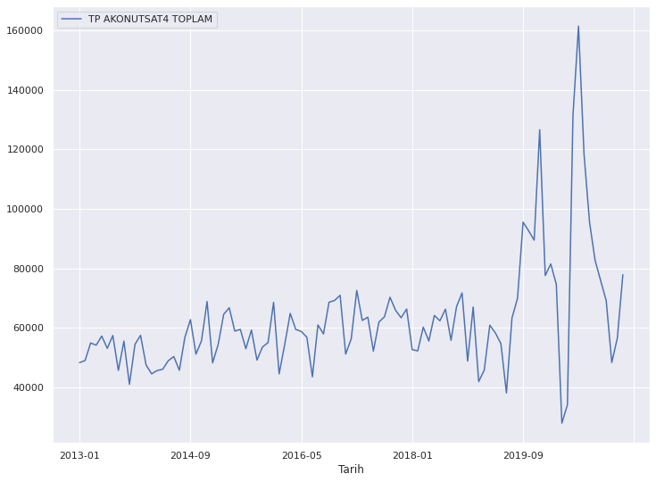

```python
sns.set(rc={'figure.figsize':(12,9)})
df.plot()
plt.show()
```

It is hard to say that there is a trend. But if we ignore unusual observations after 2019, it is possible to say that there is an upward trend. So, I added a trend variable.

```python
df['trend'] = np.linspace(1,len(df),len(df))
df.head()
```

| Tarih | TP AKONUTSAT4 TOPLAM | trend |
| --- | --- | --- |
| 2013-01 | 48281 | 1.0 |
| 2013-02 | 48998 | 2.0 |
| 2013-03 | 54904 | 3.0 |
| 2013-04 | 54148 | 4.0 |
| 2013-05 | 57212 | 5.0 |

If we visualize data with trend variable, it seems visually justifiable except for outlier situtations.

```
[]
```

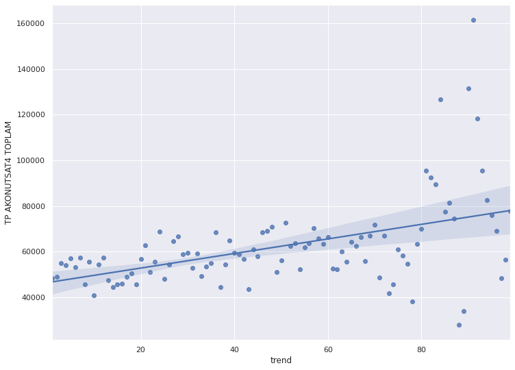

```python
ax = sns.regplot(x="trend", y="TP AKONUTSAT4 TOPLAM", data=df)
plt.plot()
```

```python
lm = sm.OLS(df["TP AKONUTSAT4 TOPLAM"].astype(float),df["trend"])
model = lm.fit()
model.summary()
```

OLS Regression Results

| Dep. Variable: | TP AKONUTSAT4 TOPLAM | R-squared (uncentered): | 0.807 |
| --- | --- | --- | --- |
| Model: | OLS | Adj. R-squared (uncentered): | 0.805 |
| Method: | Least Squares | F-statistic: | 410.2 |
| Date: | Thu, 06 May 2021 | Prob (F-statistic): | 8.44e-37 |
| Time: | 21:29:18 | Log-Likelihood: | -1156.6 |
| No. Observations: | 99 | AIC: | 2315. |
| Df Residuals: | 98 | BIC: | 2318. |
| Df Model: | 1 |  |  |
| Covariance Type: | nonrobust |  |  |

|  | coef | std err | t | P>\|t\| | [0.025 | 0.975] |
| --- | --- | --- | --- | --- | --- | --- |
| trend | 1018.9315 | 50.311 | 20.253 | 0.000 | 919.092 | 1118.771 |

| Omnibus: | 3.940 | Durbin-Watson: | 0.355 |
| --- | --- | --- | --- |
| Prob(Omnibus): | 0.139 | Jarque-Bera (JB): | 3.806 |
| Skew: | -0.478 | Prob(JB): | 0.149 |
| Kurtosis: | 2.905 | Cond. No. | 1.00 |

Warnings:  
[1] Standard Errors assume that the covariance matrix of the errors is correctly specified.

I checked the results of OLS regression. According to results, trend variable have a power of explaining the model.

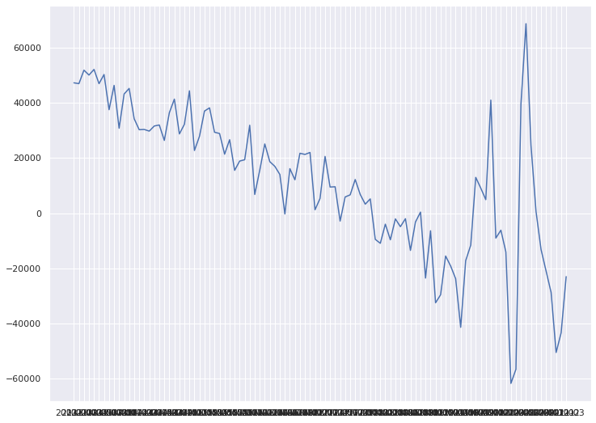

```python
plt.plot(model.resid)
plt.show()
```

Moreover, we can see high autocorrelation levels. To handle it, we can add seasonality variable.

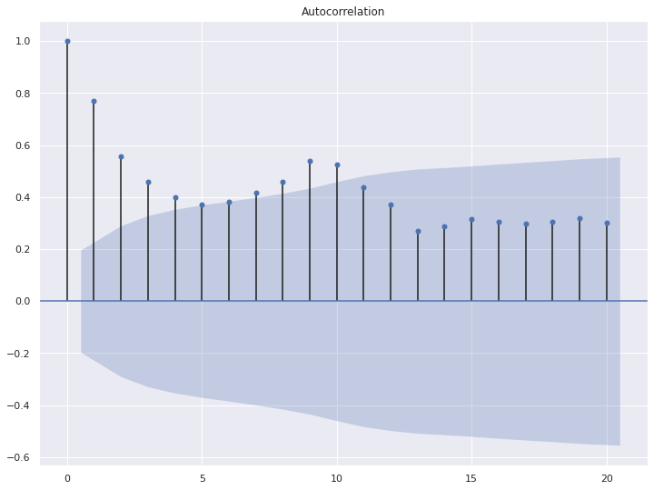

```python
plot_acf(model.resid)
plt.show()
```

```python
df['month'] = pd.DatetimeIndex(df.index).month
df.head()
```

| Tarih | TP AKONUTSAT4 TOPLAM | trend | month |
| --- | --- | --- | --- |
| 2013-01 | 48281 | 1.0 | 1 |
| 2013-02 | 48998 | 2.0 | 2 |
| 2013-03 | 54904 | 3.0 | 3 |
| 2013-04 | 54148 | 4.0 | 4 |
| 2013-05 | 57212 | 5.0 | 5 |

```python
X = df.drop("TP AKONUTSAT4 TOPLAM", axis = 1)
X.head()
```

| Tarih | trend | month |
| --- | --- | --- |
| 2013-01 | 1.0 | 1 |
| 2013-02 | 2.0 | 2 |
| 2013-03 | 3.0 | 3 |
| 2013-04 | 4.0 | 4 |
| 2013-05 | 5.0 | 5 |

```python
y = df["TP AKONUTSAT4 TOPLAM"]
y.head()
```

```
Tarih
2013-01    48281
2013-02    48998
2013-03    54904
2013-04    54148
2013-05    57212
Name: TP AKONUTSAT4 TOPLAM, dtype: int64
```

```python
lm = sm.OLS(y.astype(float),X)
model = lm.fit()
model.summary()
```

OLS Regression Results

| Dep. Variable: | TP AKONUTSAT4 TOPLAM | R-squared (uncentered): | 0.892 |
| --- | --- | --- | --- |
| Model: | OLS | Adj. R-squared (uncentered): | 0.889 |
| Method: | Least Squares | F-statistic: | 399.2 |
| Date: | Thu, 06 May 2021 | Prob (F-statistic): | 1.54e-47 |
| Time: | 21:29:29 | Log-Likelihood: | -1128.1 |
| No. Observations: | 99 | AIC: | 2260. |
| Df Residuals: | 97 | BIC: | 2265. |
| Df Model: | 2 |  |  |
| Covariance Type: | nonrobust |  |  |

|  | coef | std err | t | P>\|t\| | [0.025 | 0.975] |
| --- | --- | --- | --- | --- | --- | --- |
| trend | 616.7620 | 59.783 | 10.317 | 0.000 | 498.109 | 735.415 |
| month | 4126.8944 | 474.420 | 8.699 | 0.000 | 3185.303 | 5068.486 |

| Omnibus: | 2.813 | Durbin-Watson: | 0.624 |
| --- | --- | --- | --- |
| Prob(Omnibus): | 0.245 | Jarque-Bera (JB): | 2.324 |
| Skew: | 0.205 | Prob(JB): | 0.313 |
| Kurtosis: | 3.629 | Cond. No. | 12.6 |

Warnings:  
[1] Standard Errors assume that the covariance matrix of the errors is correctly specified.

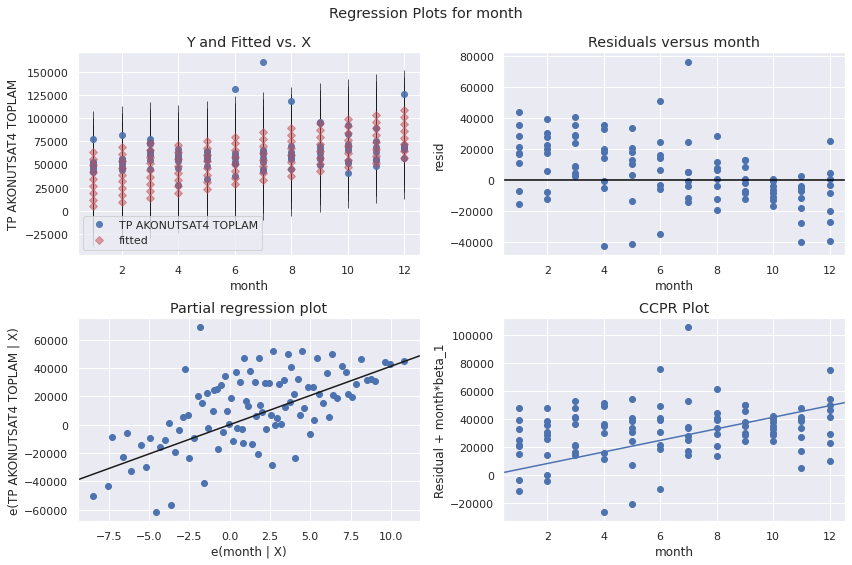

```python
fig = plt.figure(figsize=(12,8))
fig = sm.graphics.plot_regress_exog(model, 'month', fig=fig)
```

The distribution of residuals became more normal after adding seasonality variable.

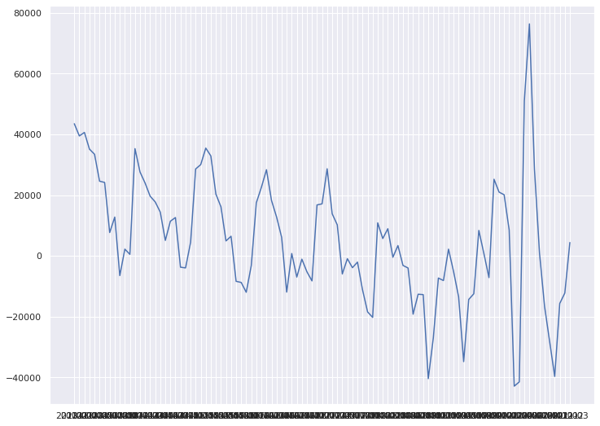

```python
plt.plot(model.resid)
plt.show()
```

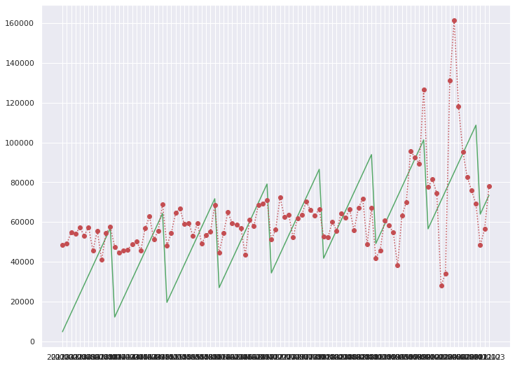

```python
df_estimated = pd.DataFrame(model.fittedvalues,  index = model.fittedvalues.index)
df_estimated["Ground Truth"] = df["TP AKONUTSAT4 TOPLAM"]
plt.plot(df_estimated[df_estimated.columns[0]], "g")
plt.plot(df_estimated["Ground Truth"], "r:o")
plt.show()
```

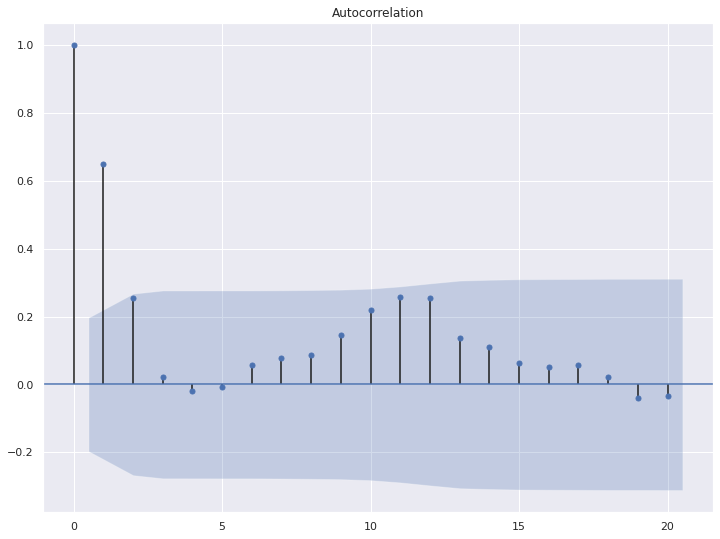

```python
plot_acf(model.resid)
plt.show()
```

There is still autocorrelation. I decided to use the lag as regressor in the model.

```python
lag = 1
df["lag"] = df["TP AKONUTSAT4 TOPLAM"].shift(lag)
df = df.drop(df.head(lag).index) # Remove First month data
```

```python
df.head()
```

| Tarih | TP AKONUTSAT4 TOPLAM | trend | month | lag |
| --- | --- | --- | --- | --- |
| 2013-02 | 48998 | 2.0 | 2 | 48281.0 |
| 2013-03 | 54904 | 3.0 | 3 | 48998.0 |
| 2013-04 | 54148 | 4.0 | 4 | 54904.0 |
| 2013-05 | 57212 | 5.0 | 5 | 54148.0 |
| 2013-06 | 53079 | 6.0 | 6 | 57212.0 |

```python
X = df.drop("TP AKONUTSAT4 TOPLAM", axis = 1)
X.head()
```

| Tarih | trend | month | lag |
| --- | --- | --- | --- |
| 2013-02 | 2.0 | 2 | 48281.0 |
| 2013-03 | 3.0 | 3 | 48998.0 |
| 2013-04 | 4.0 | 4 | 54904.0 |
| 2013-05 | 5.0 | 5 | 54148.0 |
| 2013-06 | 6.0 | 6 | 57212.0 |

```python
y = df["TP AKONUTSAT4 TOPLAM"]
y.head()
```

```
Tarih
2013-02    48998
2013-03    54904
2013-04    54148
2013-05    57212
2013-06    53079
Name: TP AKONUTSAT4 TOPLAM, dtype: int64
```

```python
df.tail()
```

| Tarih | TP AKONUTSAT4 TOPLAM | trend | month | lag |
| --- | --- | --- | --- | --- |
| 2020-11 | 75825 | 95.0 | 11 | 82598.0 |
| 2020-12 | 69083 | 96.0 | 12 | 75825.0 |
| 2021-01 | 48319 | 97.0 | 1 | 69083.0 |
| 2021-02 | 56485 | 98.0 | 2 | 48319.0 |
| 2021-03 | 77876 | 99.0 | 3 | 56485.0 |

```python
lm = sm.OLS(y.astype(float),X.astype(float))
model = lm.fit()
model.summary()
```

OLS Regression Results

| Dep. Variable: | TP AKONUTSAT4 TOPLAM | R-squared (uncentered): | 0.948 |
| --- | --- | --- | --- |
| Model: | OLS | Adj. R-squared (uncentered): | 0.946 |
| Method: | Least Squares | F-statistic: | 571.6 |
| Date: | Thu, 06 May 2021 | Prob (F-statistic): | 1.22e-60 |
| Time: | 21:30:44 | Log-Likelihood: | -1081.4 |
| No. Observations: | 98 | AIC: | 2169. |
| Df Residuals: | 95 | BIC: | 2177. |
| Df Model: | 3 |  |  |
| Covariance Type: | nonrobust |  |  |

|  | coef | std err | t | P>\|t\| | [0.025 | 0.975] |
| --- | --- | --- | --- | --- | --- | --- |
| trend | 186.9009 | 61.161 | 3.056 | 0.003 | 65.481 | 308.321 |
| month | 1769.4116 | 411.080 | 4.304 | 0.000 | 953.314 | 2585.509 |
| lag | 0.6503 | 0.067 | 9.694 | 0.000 | 0.517 | 0.784 |

| Omnibus: | 50.048 | Durbin-Watson: | 1.657 |
| --- | --- | --- | --- |
| Prob(Omnibus): | 0.000 | Jarque-Bera (JB): | 308.959 |
| Skew: | 1.448 | Prob(JB): | 8.13e-68 |
| Kurtosis: | 11.202 | Cond. No. | 1.74e+04 |

Warnings:  
[1] Standard Errors assume that the covariance matrix of the errors is correctly specified.  
[2] The condition number is large, 1.74e+04. This might indicate that there are  
strong multicollinearity or other numerical problems.

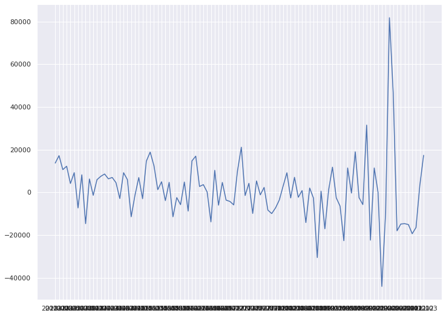

```python
plt.plot(model.resid)
plt.show()
```

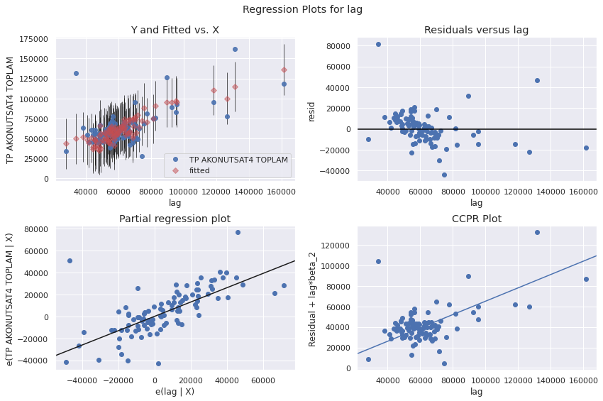

```python
fig = plt.figure(figsize=(12,8))
fig = sm.graphics.plot_regress_exog(model, 'lag', fig=fig)
```

Autocorrelation seems to achieve desired level.

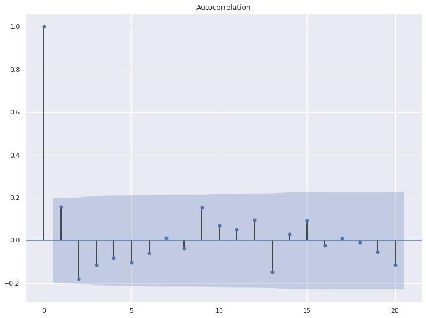

```python
plot_acf(model.resid)
plt.show()
```

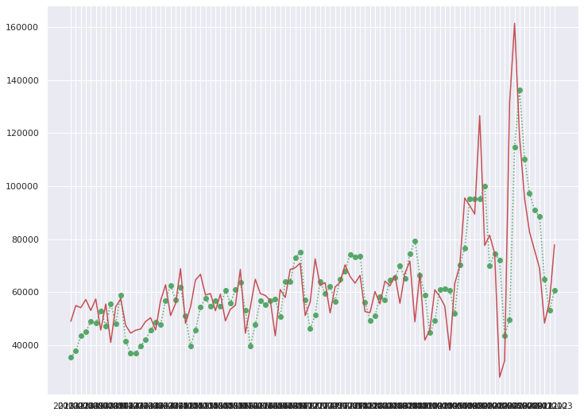

```python
df_estimated = pd.DataFrame(model.fittedvalues,  index = model.fittedvalues.index)
df_estimated["Ground Truth"] = df["TP AKONUTSAT4 TOPLAM"]
plt.plot(df_estimated[df_estimated.columns[0]], "g:o")
plt.plot(df_estimated["Ground Truth"], "r")
plt.show()
```

```python
df["TP AKONUTSAT4 TOPLAM"].tail(1)
```

```
Tarih
2021-03    77876
Name: TP AKONUTSAT4 TOPLAM, dtype: int64
```

```python
model.predict(pd.DataFrame.from_dict({"trend":[100.0],"month":[4],"lag":[float(df["TP AKONUTSAT4 TOPLAM"].tail(1))]}))
```

```
0    76413.670164
dtype: float64
```

I added House Credit İnterest Rates data as predictor. As a Turkey citizen, I can say that a considerable number of people buy their house with debt. So, interest rates is one of the key driver of second hand house sales.

```python
interest_rates = pd.read_excel("EVDS (11).xlsx")
```

```python
interest_rates.tail()
```

|  | Date | TP KTF12 |
| --- | --- | --- |
| 214 | 2020-11 | 15.6750 |
| 215 | 2020-12 | 18.1925 |
| 216 | 2021-01 | 18.3880 |
| 217 | 2021-02 | 17.9850 |
| 218 | 2021-03 | 17.7350 |

```python
df = df.join(interest_rates.set_index("Date"))
```

```python
X = df.drop("TP AKONUTSAT4 TOPLAM", axis = 1)
X.head()
```

| Tarih | trend | month | lag | TP KTF12 |
| --- | --- | --- | --- | --- |
| 2013-02 | 2.0 | 2 | 48281.0 | 9.5775 |
| 2013-03 | 3.0 | 3 | 48998.0 | 9.3060 |
| 2013-04 | 4.0 | 4 | 54904.0 | 9.0575 |
| 2013-05 | 5.0 | 5 | 54148.0 | 8.7660 |
| 2013-06 | 6.0 | 6 | 57212.0 | 8.2975 |

```python
y = df["TP AKONUTSAT4 TOPLAM"]
y.head()
```

```
Tarih
2013-02    48998
2013-03    54904
2013-04    54148
2013-05    57212
2013-06    53079
Name: TP AKONUTSAT4 TOPLAM, dtype: int64
```

```python
df.tail()
```

| Tarih | TP AKONUTSAT4 TOPLAM | trend | month | lag | TP KTF12 |
| --- | --- | --- | --- | --- | --- |
| 2020-11 | 75825 | 95.0 | 11 | 82598.0 | 15.6750 |
| 2020-12 | 69083 | 96.0 | 12 | 75825.0 | 18.1925 |
| 2021-01 | 48319 | 97.0 | 1 | 69083.0 | 18.3880 |
| 2021-02 | 56485 | 98.0 | 2 | 48319.0 | 17.9850 |
| 2021-03 | 77876 | 99.0 | 3 | 56485.0 | 17.7350 |

```python
lm = sm.OLS(y.astype(float),X.astype(float))
model = lm.fit()
model.summary()
```

OLS Regression Results

| Dep. Variable: | TP AKONUTSAT4 TOPLAM | R-squared (uncentered): | 0.948 |
| --- | --- | --- | --- |
| Model: | OLS | Adj. R-squared (uncentered): | 0.945 |
| Method: | Least Squares | F-statistic: | 424.5 |
| Date: | Thu, 06 May 2021 | Prob (F-statistic): | 3.08e-59 |
| Time: | 21:54:07 | Log-Likelihood: | -1081.4 |
| No. Observations: | 98 | AIC: | 2171. |
| Df Residuals: | 94 | BIC: | 2181. |
| Df Model: | 4 |  |  |
| Covariance Type: | nonrobust |  |  |

|  | coef | std err | t | P>\|t\| | [0.025 | 0.975] |
| --- | --- | --- | --- | --- | --- | --- |
| trend | 195.8755 | 70.571 | 2.776 | 0.007 | 55.755 | 335.996 |
| month | 1811.7985 | 444.395 | 4.077 | 0.000 | 929.443 | 2694.155 |
| lag | 0.6553 | 0.070 | 9.355 | 0.000 | 0.516 | 0.794 |
| TP KTF12 | -80.3817 | 310.588 | -0.259 | 0.796 | -697.061 | 536.298 |

| Omnibus: | 48.099 | Durbin-Watson: | 1.660 |
| --- | --- | --- | --- |
| Prob(Omnibus): | 0.000 | Jarque-Bera (JB): | 288.586 |
| Skew: | 1.385 | Prob(JB): | 2.16e-63 |
| Kurtosis: | 10.937 | Cond. No. | 1.97e+04 |

Warnings:  
[1] Standard Errors assume that the covariance matrix of the errors is correctly specified.  
[2] The condition number is large, 1.97e+04. This might indicate that there are  
strong multicollinearity or other numerical problems.

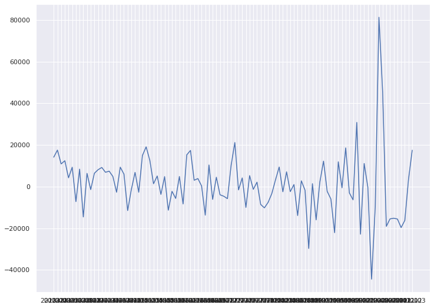

```python
plt.plot(model.resid)
plt.show()
```

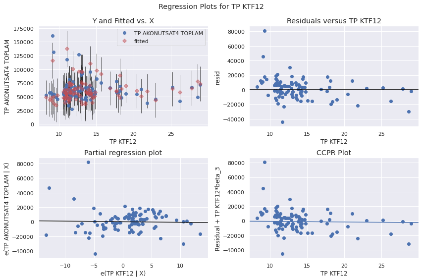

```python
fig = plt.figure(figsize=(12,8))
fig = sm.graphics.plot_regress_exog(model, "TP KTF12", fig=fig)
```

There is no a significant autocorrelation

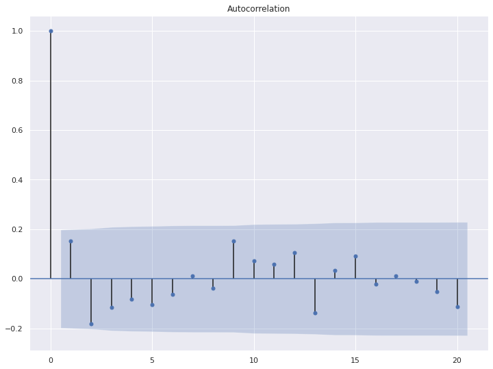

```python
plot_acf(model.resid)
plt.show()
```

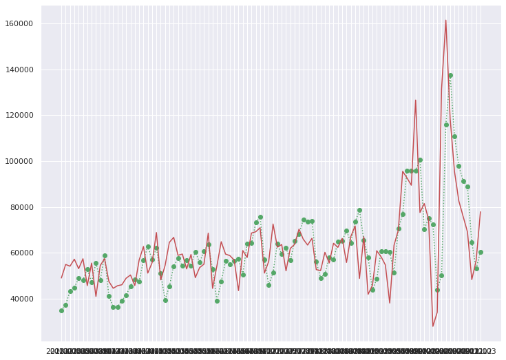

```python
df_estimated = pd.DataFrame(model.fittedvalues,  index = model.fittedvalues.index)
df_estimated["Ground Truth"] = df["TP AKONUTSAT4 TOPLAM"]
plt.plot(df_estimated[df_estimated.columns[0]], "g:o")
plt.plot(df_estimated["Ground Truth"], "r")
plt.show()
```

```python
model.predict(pd.DataFrame.from_dict({
    "trend":[100.0],
    "month":[4],
    "lag":[float(df["TP AKONUTSAT4 TOPLAM"].tail(1))],
    "TP KTF12":[df["TP KTF12"].tail(1)]}))
```

```
0    Tarih
2021-03    76437.896639
Name: TP KTF12, ...
dtype: object
```